# customer_churn_project

```python
import pandas as pd
import numpy as np
import matplotlib.pyplot as plt
import seaborn as sns
```

```python
data = pd.read_csv('customer_churn.csv')
```

```python
data.head()
```

|  | customerID | gender | SeniorCitizen | Partner | Dependents | tenure | PhoneService | MultipleLines | InternetService | OnlineSecurity | ... | DeviceProtection | TechSupport | StreamingTV | StreamingMovies | Contract | PaperlessBilling | PaymentMethod | MonthlyCharges | TotalCharges | Churn |
| --- | --- | --- | --- | --- | --- | --- | --- | --- | --- | --- | --- | --- | --- | --- | --- | --- | --- | --- | --- | --- | --- |
| 0 | 7590-VHVEG | Female | 0 | Yes | No | 1 | No | No phone service | DSL | No | ... | No | No | No | No | Month-to-month | Yes | Electronic check | 29.85 | 29.85 | No |
| 1 | 5575-GNVDE | Male | 0 | No | No | 34 | Yes | No | DSL | Yes | ... | Yes | No | No | No | One year | No | Mailed check | 56.95 | 1889.5 | No |
| 2 | 3668-QPYBK | Male | 0 | No | No | 2 | Yes | No | DSL | Yes | ... | No | No | No | No | Month-to-month | Yes | Mailed check | 53.85 | 108.15 | Yes |
| 3 | 7795-CFOCW | Male | 0 | No | No | 45 | No | No phone service | DSL | Yes | ... | Yes | Yes | No | No | One year | No | Bank transfer (automatic) | 42.30 | 1840.75 | No |
| 4 | 9237-HQITU | Female | 0 | No | No | 2 | Yes | No | Fiber optic | No | ... | No | No | No | No | Month-to-month | Yes | Electronic check | 70.70 | 151.65 | Yes |

5 rows × 21 columns

```python
data.tail()
```

|  | customerID | gender | SeniorCitizen | Partner | Dependents | tenure | PhoneService | MultipleLines | InternetService | OnlineSecurity | ... | DeviceProtection | TechSupport | StreamingTV | StreamingMovies | Contract | PaperlessBilling | PaymentMethod | MonthlyCharges | TotalCharges | Churn |
| --- | --- | --- | --- | --- | --- | --- | --- | --- | --- | --- | --- | --- | --- | --- | --- | --- | --- | --- | --- | --- | --- |
| 7038 | 6840-RESVB | Male | 0 | Yes | Yes | 24 | Yes | Yes | DSL | Yes | ... | Yes | Yes | Yes | Yes | One year | Yes | Mailed check | 84.80 | 1990.5 | No |
| 7039 | 2234-XADUH | Female | 0 | Yes | Yes | 72 | Yes | Yes | Fiber optic | No | ... | Yes | No | Yes | Yes | One year | Yes | Credit card (automatic) | 103.20 | 7362.9 | No |
| 7040 | 4801-JZAZL | Female | 0 | Yes | Yes | 11 | No | No phone service | DSL | Yes | ... | No | No | No | No | Month-to-month | Yes | Electronic check | 29.60 | 346.45 | No |
| 7041 | 8361-LTMKD | Male | 1 | Yes | No | 4 | Yes | Yes | Fiber optic | No | ... | No | No | No | No | Month-to-month | Yes | Mailed check | 74.40 | 306.6 | Yes |
| 7042 | 3186-AJIEK | Male | 0 | No | No | 66 | Yes | No | Fiber optic | Yes | ... | Yes | Yes | Yes | Yes | Two year | Yes | Bank transfer (automatic) | 105.65 | 6844.5 | No |

5 rows × 21 columns

```python
data.info()
```

```
<class 'pandas.core.frame.DataFrame'>
RangeIndex: 7043 entries, 0 to 7042
Data columns (total 21 columns):
 #   Column            Non-Null Count  Dtype
---  ------            --------------  -----
 0   customerID        7043 non-null   object
 1   gender            7043 non-null   object
 2   SeniorCitizen     7043 non-null   int64
 3   Partner           7043 non-null   object
 4   Dependents        7043 non-null   object
 5   tenure            7043 non-null   int64
 6   PhoneService      7043 non-null   object
 7   MultipleLines     7043 non-null   object
 8   InternetService   7043 non-null   object
 9   OnlineSecurity    7043 non-null   object
 10  OnlineBackup      7043 non-null   object
 11  DeviceProtection  7043 non-null   object
 12  TechSupport       7043 non-null   object
 13  StreamingTV       7043 non-null   object
 14  StreamingMovies   7043 non-null   object
 15  Contract          7043 non-null   object
 16  PaperlessBilling  7043 non-null   object
 17  PaymentMethod     7043 non-null   object
 18  MonthlyCharges    7043 non-null   float64
 19  TotalCharges      7043 non-null   object
 20  Churn             7043 non-null   object
dtypes: float64(1), int64(2), object(18)
memory usage: 1.1+ MB
```

```python
data.columns
```

```
Index(['customerID', 'gender', 'SeniorCitizen', 'Partner', 'Dependents',
       'tenure', 'PhoneService', 'MultipleLines', 'InternetService',
       'OnlineSecurity', 'OnlineBackup', 'DeviceProtection', 'TechSupport',
       'StreamingTV', 'StreamingMovies', 'Contract', 'PaperlessBilling',
       'PaymentMethod', 'MonthlyCharges', 'TotalCharges', 'Churn'],
      dtype='object')
```

```python
#Extract the 5th column and store it in ‘customer_5’

customer_5 = data.iloc[: , 4:5]
```

```python
customer_5
```

|  | Dependents |
| --- | --- |
| 0 | No |
| 1 | No |
| 2 | No |
| 3 | No |
| 4 | No |
| ... | ... |
| 7038 | Yes |
| 7039 | Yes |
| 7040 | Yes |
| 7041 | No |
| 7042 | No |

7043 rows × 1 columns

```python
#Extract the 15th column and store it in ‘customer_15’

customer_15 = data.iloc[:,14:15]
customer_15
```

|  | StreamingMovies |
| --- | --- |
| 0 | No |
| 1 | No |
| 2 | No |
| 3 | No |
| 4 | No |
| ... | ... |
| 7038 | Yes |
| 7039 | Yes |
| 7040 | No |
| 7041 | No |
| 7042 | Yes |

7043 rows × 1 columns

```python
# Extract all the male senior citizens whose payment method is electronic
#  check and store the result in ‘senior_male_electronic’
senior_male_electronic = data[(data['gender']=='Male') & (data['SeniorCitizen']==1) & (data['PaymentMethod']=='Electronic check')]
```

```python
senior_male_electronic
```

|  | customerID | gender | SeniorCitizen | Partner | Dependents | tenure | PhoneService | MultipleLines | InternetService | OnlineSecurity | ... | DeviceProtection | TechSupport | StreamingTV | StreamingMovies | Contract | PaperlessBilling | PaymentMethod | MonthlyCharges | TotalCharges | Churn |
| --- | --- | --- | --- | --- | --- | --- | --- | --- | --- | --- | --- | --- | --- | --- | --- | --- | --- | --- | --- | --- | --- |
| 20 | 8779-QRDMV | Male | 1 | No | No | 1 | No | No phone service | DSL | No | ... | Yes | No | No | Yes | Month-to-month | Yes | Electronic check | 39.65 | 39.65 | Yes |
| 55 | 1658-BYGOY | Male | 1 | No | No | 18 | Yes | Yes | Fiber optic | No | ... | No | No | Yes | Yes | Month-to-month | Yes | Electronic check | 95.45 | 1752.55 | Yes |
| 57 | 5067-XJQFU | Male | 1 | Yes | Yes | 66 | Yes | Yes | Fiber optic | No | ... | Yes | Yes | Yes | Yes | One year | Yes | Electronic check | 108.45 | 7076.35 | No |
| 78 | 0191-ZHSKZ | Male | 1 | No | No | 30 | Yes | No | DSL | Yes | ... | No | No | Yes | Yes | Month-to-month | Yes | Electronic check | 74.75 | 2111.3 | No |
| 91 | 2424-WVHPL | Male | 1 | No | No | 1 | Yes | No | Fiber optic | No | ... | No | Yes | No | No | Month-to-month | No | Electronic check | 74.70 | 74.7 | No |
| ... | ... | ... | ... | ... | ... | ... | ... | ... | ... | ... | ... | ... | ... | ... | ... | ... | ... | ... | ... | ... | ... |
| 6837 | 6229-LSCKB | Male | 1 | No | No | 6 | Yes | No | Fiber optic | No | ... | No | No | Yes | No | Month-to-month | Yes | Electronic check | 79.70 | 497.6 | No |
| 6894 | 1400-MMYXY | Male | 1 | Yes | No | 3 | Yes | Yes | Fiber optic | No | ... | Yes | No | Yes | Yes | Month-to-month | Yes | Electronic check | 105.90 | 334.65 | Yes |
| 6914 | 7142-HVGBG | Male | 1 | Yes | No | 43 | Yes | Yes | Fiber optic | No | ... | Yes | No | Yes | Yes | Month-to-month | Yes | Electronic check | 103.00 | 4414.3 | Yes |
| 6967 | 8739-WWKDU | Male | 1 | No | No | 25 | Yes | Yes | Fiber optic | No | ... | No | No | Yes | No | Month-to-month | Yes | Electronic check | 89.50 | 2196.15 | Yes |
| 7032 | 6894-LFHLY | Male | 1 | No | No | 1 | Yes | Yes | Fiber optic | No | ... | No | No | No | No | Month-to-month | Yes | Electronic check | 75.75 | 75.75 | Yes |

298 rows × 21 columns

Extract all those customers whose tenure is greater than 70 months or their monthly charges is more than $100 and store the result in ‘customer_total_tenure’ Extract all the customers whose contract is of two years, payment method is mailed check and the value of churn is ‘Yes’ and store the result in ‘two_mail_yes’

```python
customer_total_tenure = data[(data['tenure'] > 70) | (data['MonthlyCharges'] > 100)]
customer_total_tenure
```

|  | customerID | gender | SeniorCitizen | Partner | Dependents | tenure | PhoneService | MultipleLines | InternetService | OnlineSecurity | ... | DeviceProtection | TechSupport | StreamingTV | StreamingMovies | Contract | PaperlessBilling | PaymentMethod | MonthlyCharges | TotalCharges | Churn |
| --- | --- | --- | --- | --- | --- | --- | --- | --- | --- | --- | --- | --- | --- | --- | --- | --- | --- | --- | --- | --- | --- |
| 8 | 7892-POOKP | Female | 0 | Yes | No | 28 | Yes | Yes | Fiber optic | No | ... | Yes | Yes | Yes | Yes | Month-to-month | Yes | Electronic check | 104.80 | 3046.05 | Yes |
| 12 | 8091-TTVAX | Male | 0 | Yes | No | 58 | Yes | Yes | Fiber optic | No | ... | Yes | No | Yes | Yes | One year | No | Credit card (automatic) | 100.35 | 5681.1 | No |
| 13 | 0280-XJGEX | Male | 0 | No | No | 49 | Yes | Yes | Fiber optic | No | ... | Yes | No | Yes | Yes | Month-to-month | Yes | Bank transfer (automatic) | 103.70 | 5036.3 | Yes |
| 14 | 5129-JLPIS | Male | 0 | No | No | 25 | Yes | No | Fiber optic | Yes | ... | Yes | Yes | Yes | Yes | Month-to-month | Yes | Electronic check | 105.50 | 2686.05 | No |
| 15 | 3655-SNQYZ | Female | 0 | Yes | Yes | 69 | Yes | Yes | Fiber optic | Yes | ... | Yes | Yes | Yes | Yes | Two year | No | Credit card (automatic) | 113.25 | 7895.15 | No |
| ... | ... | ... | ... | ... | ... | ... | ... | ... | ... | ... | ... | ... | ... | ... | ... | ... | ... | ... | ... | ... | ... |
| 7023 | 1035-IPQPU | Female | 1 | Yes | No | 63 | Yes | Yes | Fiber optic | No | ... | Yes | No | Yes | Yes | Month-to-month | Yes | Electronic check | 103.50 | 6479.4 | No |
| 7034 | 0639-TSIQW | Female | 0 | No | No | 67 | Yes | Yes | Fiber optic | Yes | ... | Yes | No | Yes | No | Month-to-month | Yes | Credit card (automatic) | 102.95 | 6886.25 | Yes |
| 7037 | 2569-WGERO | Female | 0 | No | No | 72 | Yes | No | No | No internet service | ... | No internet service | No internet service | No internet service | No internet service | Two year | Yes | Bank transfer (automatic) | 21.15 | 1419.4 | No |
| 7039 | 2234-XADUH | Female | 0 | Yes | Yes | 72 | Yes | Yes | Fiber optic | No | ... | Yes | No | Yes | Yes | One year | Yes | Credit card (automatic) | 103.20 | 7362.9 | No |
| 7042 | 3186-AJIEK | Male | 0 | No | No | 66 | Yes | No | Fiber optic | Yes | ... | Yes | Yes | Yes | Yes | Two year | Yes | Bank transfer (automatic) | 105.65 | 6844.5 | No |

1259 rows × 21 columns

Extract all the customers whose contract is of two years, payment method is mailed check and the value of churn is ‘Yes’ and store the result in ‘two_mail_yes’

```python
two_mail_yes = data[(data['Contract'] == 'Two year') & (data['PaymentMethod'] =='Mailed check') & (data['Churn'] == 'Yes')]
two_mail_yes
```

|  | customerID | gender | SeniorCitizen | Partner | Dependents | tenure | PhoneService | MultipleLines | InternetService | OnlineSecurity | ... | DeviceProtection | TechSupport | StreamingTV | StreamingMovies | Contract | PaperlessBilling | PaymentMethod | MonthlyCharges | TotalCharges | Churn |
| --- | --- | --- | --- | --- | --- | --- | --- | --- | --- | --- | --- | --- | --- | --- | --- | --- | --- | --- | --- | --- | --- |
| 268 | 6323-AYBRX | Male | 0 | No | No | 59 | Yes | No | No | No internet service | ... | No internet service | No internet service | No internet service | No internet service | Two year | No | Mailed check | 19.35 | 1099.6 | Yes |
| 5947 | 7951-QKZPL | Female | 0 | Yes | Yes | 33 | Yes | Yes | No | No internet service | ... | No internet service | No internet service | No internet service | No internet service | Two year | Yes | Mailed check | 24.50 | 740.3 | Yes |
| 6680 | 9412-ARGBX | Female | 0 | No | Yes | 48 | Yes | No | Fiber optic | No | ... | Yes | Yes | Yes | No | Two year | Yes | Mailed check | 95.50 | 4627.85 | Yes |

3 rows × 21 columns

```python
two_mail_yes = data[(data['Contract'] == 'Two year') & (data['PaymentMethod'] == 'Mailed check') & (data['Churn'] == 'Yes')]
two_mail_yes
```

|  | customerID | gender | SeniorCitizen | Partner | Dependents | tenure | PhoneService | MultipleLines | InternetService | OnlineSecurity | ... | DeviceProtection | TechSupport | StreamingTV | StreamingMovies | Contract | PaperlessBilling | PaymentMethod | MonthlyCharges | TotalCharges | Churn |
| --- | --- | --- | --- | --- | --- | --- | --- | --- | --- | --- | --- | --- | --- | --- | --- | --- | --- | --- | --- | --- | --- |
| 268 | 6323-AYBRX | Male | 0 | No | No | 59 | Yes | No | No | No internet service | ... | No internet service | No internet service | No internet service | No internet service | Two year | No | Mailed check | 19.35 | 1099.6 | Yes |
| 5947 | 7951-QKZPL | Female | 0 | Yes | Yes | 33 | Yes | Yes | No | No internet service | ... | No internet service | No internet service | No internet service | No internet service | Two year | Yes | Mailed check | 24.50 | 740.3 | Yes |
| 6680 | 9412-ARGBX | Female | 0 | No | Yes | 48 | Yes | No | Fiber optic | No | ... | Yes | Yes | Yes | No | Two year | Yes | Mailed check | 95.50 | 4627.85 | Yes |

3 rows × 21 columns

Extract 333 random records from the customer_churndataframe and store the result in ‘customer_333’

```python
customer_333 = data.sample(n=333)
```

```python
customer_333
```

|  | customerID | gender | SeniorCitizen | Partner | Dependents | tenure | PhoneService | MultipleLines | InternetService | OnlineSecurity | ... | DeviceProtection | TechSupport | StreamingTV | StreamingMovies | Contract | PaperlessBilling | PaymentMethod | MonthlyCharges | TotalCharges | Churn |
| --- | --- | --- | --- | --- | --- | --- | --- | --- | --- | --- | --- | --- | --- | --- | --- | --- | --- | --- | --- | --- | --- |
| 2745 | 4826-XTSOH | Male | 1 | Yes | No | 1 | Yes | Yes | Fiber optic | No | ... | No | No | Yes | No | Month-to-month | Yes | Electronic check | 86.05 | 86.05 | Yes |
| 536 | 0621-HJWXJ | Female | 0 | Yes | No | 63 | Yes | Yes | Fiber optic | No | ... | No | No | No | No | Month-to-month | Yes | Bank transfer (automatic) | 81.55 | 5029.05 | No |
| 5395 | 9095-HFAFX | Female | 0 | No | No | 5 | Yes | No | Fiber optic | No | ... | No | No | Yes | No | Month-to-month | Yes | Credit card (automatic) | 81.00 | 389.6 | Yes |
| 169 | 1159-WFSGR | Female | 0 | Yes | Yes | 16 | Yes | No | No | No internet service | ... | No internet service | No internet service | No internet service | No internet service | Month-to-month | No | Electronic check | 20.40 | 321.4 | No |
| 395 | 2977-CEBSX | Female | 0 | No | No | 66 | Yes | Yes | DSL | Yes | ... | Yes | Yes | Yes | Yes | Two year | Yes | Credit card (automatic) | 90.05 | 5965.95 | No |
| ... | ... | ... | ... | ... | ... | ... | ... | ... | ... | ... | ... | ... | ... | ... | ... | ... | ... | ... | ... | ... | ... |
| 4406 | 3714-XPXBW | Female | 0 | No | No | 37 | Yes | Yes | DSL | Yes | ... | Yes | Yes | Yes | No | Month-to-month | Yes | Credit card (automatic) | 78.90 | 2976.95 | No |
| 2598 | 8325-QRPZR | Female | 0 | No | No | 7 | Yes | No | Fiber optic | No | ... | Yes | No | No | No | Month-to-month | Yes | Electronic check | 75.15 | 525 | No |
| 4801 | 0988-AADSA | Female | 0 | Yes | Yes | 72 | Yes | Yes | DSL | Yes | ... | Yes | Yes | No | Yes | Two year | No | Bank transfer (automatic) | 80.85 | 5824.75 | No |
| 4022 | 5863-OOKCL | Female | 0 | No | No | 10 | Yes | No | No | No internet service | ... | No internet service | No internet service | No internet service | No internet service | Month-to-month | No | Mailed check | 18.85 | 163.2 | No |
| 4638 | 7817-BOQPW | Female | 0 | No | No | 2 | Yes | Yes | Fiber optic | No | ... | No | No | No | No | Month-to-month | Yes | Electronic check | 75.55 | 166.3 | Yes |

333 rows × 21 columns

```python
#Get the count of different levels from the ‘Churn’ column
```

```python
data['Churn'].value_counts()
```

```
Churn
No     5174
Yes    1869
Name: count, dtype: int64
```

```python
ins = data['InternetService'].value_counts()
ins
```

```
InternetService
Fiber optic    3096
DSL            2421
No             1526
Name: count, dtype: int64
```

Build a bar-plot for the ’InternetService’ column: a. Set x-axis label to ‘Categories of Internet Service’ b. Set y-axis label to ‘Count of Categories’ c. Set the title of plot to be ‘Distribution of Internet Service’ d. Set the color of the bars to be ‘orange Build a histogram for the ‘tenure’ column: a. Set the number of bins to be 30 b. Set the color of the bins to be ‘green’ c. Assign the title ‘Distribution of tenure

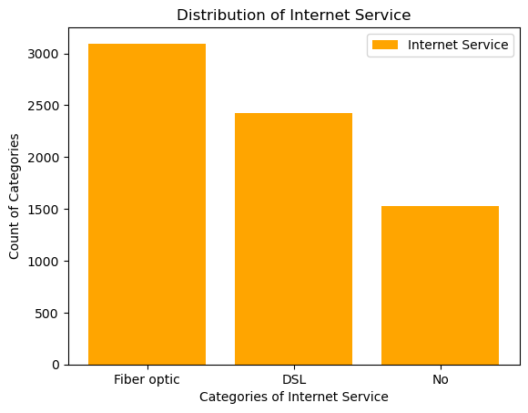

```python
plt.bar(ins.index, ins.values,color='orange',label='Internet Service')
plt.title('Distribution of Internet Service')
plt.xlabel('Categories of Internet Service')
plt.ylabel('Count of Categories')
plt.legend()
plt.show()
```

Build a histogram for the ‘tenure’ column: a. Set the number of bins to be 30 b. Set the color of the bins to be ‘green’ c. Assign the title ‘Distribution of tenure

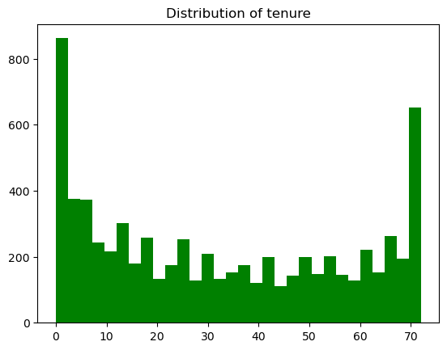

```python
plt.hist(data['tenure'],bins=30,color='green')
plt.title('Distribution of tenure')
plt.show()
```

[figure not shown]

```python
plt.scatter(data['MonthlyCharges'],data['tenure'],color='brown')
plt.xlabel("Tenure of Customer")
plt.ylabel("Monthly Charges of Customer")
plt.title("Tenure vs Monthly Charges")
plt.show()
```

e. Build a box-plot between ‘tenure’ & ‘Contract’. Map ‘tenure’ on the y-axis & f. ‘Contract’ on the x-axis.

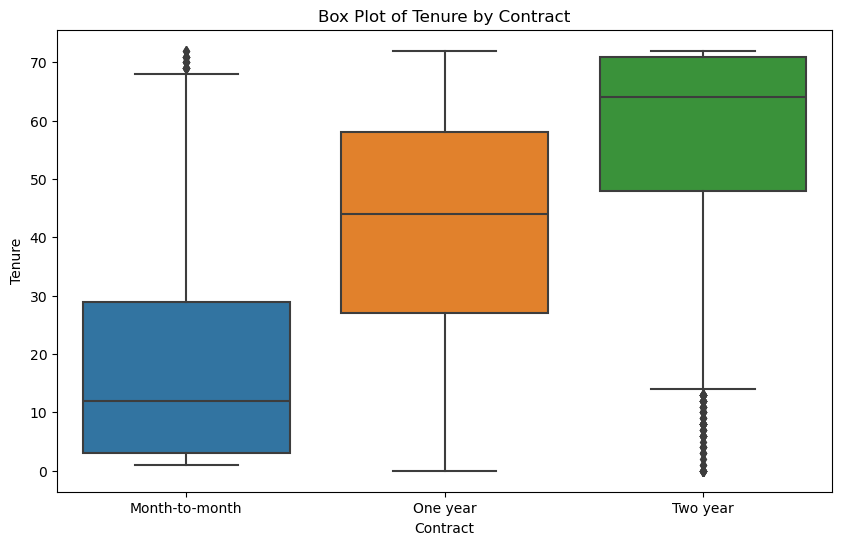

```python
plt.figure(figsize=(10,6))
sns.boxplot(x='Contract',y='tenure',data=data)
plt.xlabel('Contract')
plt.ylabel('Tenure')
plt.title('Box Plot of Tenure by Contract')
plt.show()
```

```python
# Linear Regression:
#  ● Build a simple linear model where dependent variable is ‘MonthlyCharges’
#  and independent variable is ‘tenure’:
#  a. Divide the dataset into train and test sets in 70:30 ratio.
#  b. Build the model on train set and predict the values on test set
#  c. After predicting the values, find the root mean square error
#  d. Find out the error in prediction & store the result in ‘error’
#  e. Find the root mean square error
```

[output not shown]

[output not shown]

```python
from sklearn.linear_model import LinearRegression
from sklearn.model_selection import train_test_split
from sklearn.metrics import mean_squared_error
```

```python
x = data['tenure']
y=data['MonthlyCharges']
```

```python
x
```

```
0        1
1       34
2        2
3       45
4        2
        ..
7038    24
7039    72
7040    11
7041     4
7042    66
Name: tenure, Length: 7043, dtype: int64
```

```python
y
```

```
0        29.85
1        56.95
2        53.85
3        42.30
4        70.70
         ...
7038     84.80
7039    103.20
7040     29.60
7041     74.40
7042    105.65
Name: MonthlyCharges, Length: 7043, dtype: float64
```

```python
x_train,x_test,y_train,y_test = train_test_split(x,y,train_size=0.70,random_state=42)
```

```python
model = LinearRegression()
```

```python
x_test = x_test.values.reshape(-1,1)
y_train = y_train.values.reshape(-1,1)
y_test = y_test.values.reshape(-1,1)
```

```python
x_train
```

```
1695    54
1095     1
3889    13
3667    24
2902     6
        ..
3772     1
5191    23
5226    12
5390    12
860     26
Name: tenure, Length: 4930, dtype: int64
```

```python
x_test
```

```
array([[ 1],
       [41],
       [52],
       ...,
       [60],
       [20],
       [22]], dtype=int64)
```

```python
y_train
```

```
array([[70.7 ],
       [80.55],
       [19.3 ],
       ...,
       [21.15],
       [99.45],
       [19.8 ]])
```

```python
y_test
```

```
array([[24.8 ],
       [25.25],
       [19.35],
       ...,
       [60.5 ],
       [90.7 ],
       [51.1 ]])
```

```python
model.fit(x_train,y_train)
```

[output not shown]

[output cut: 14 more lines]

[output not shown]

```python
predict = model.predict(x_test)
```

[output not shown]

```python
rmse = np.sqrt(mean_squared_error(y_test,predict))
```

[output not shown]

```python
rmse
```

[output not shown]

```python
error = predict-y_test
```

[output not shown]

```python
error
```

[output not shown]

Logistic Regression: ● Build a simple logistic regression model where dependent variable is ‘Churn’ and independent variable is ‘MonthlyCharges’: a. Divide the dataset in 65:35 ratio b. Build the model on train set and predict the values on test set c. Build the confusion matrix and get the accuracy score d. Build a multiple logistic regression model where dependent variable is ‘Churn’ and independent variables are ‘tenure’ and ‘MonthlyCharges’ e. Divide the dataset in 80:20 ratio f. Build the model on train set and predict the values on test set g. Build the confusion matrix and get the accuracy score

```python
data['Churn']
```

```
0        No
1        No
2       Yes
3        No
4       Yes
       ...
7038     No
7039     No
7040     No
7041    Yes
7042     No
Name: Churn, Length: 7043, dtype: object
```

```python
from sklearn.preprocessing import LabelEncoder
```

```python
le = LabelEncoder()
```

```python
data['Churn'] = le.fit_transform(data['Churn'])
```

```python
data['Churn']
```

```
0       0
1       0
2       1
3       0
4       1
       ..
7038    0
7039    0
7040    0
7041    1
7042    0
Name: Churn, Length: 7043, dtype: int32
```

```python
from sklearn.linear_model import LogisticRegression
```

```python
x = data[['MonthlyCharges']]
```

```python
y=data['Churn']
```

```python
x_train,x_test,y_train,y_test = train_test_split(x,y,test_size=0.35,random_state=42)
```

```python
Logmodel = LogisticRegression()
```

```python
Logmodel.fit(x_train,y_train)
```

```
LogisticRegression()
```

```python
pred = Logmodel.predict(x_test)
```

```python
pred
```

```
array([0, 0, 0, ..., 0, 0, 0])
```

```python
from sklearn.metrics import confusion_matrix, accuracy_score
```

```python
cm = confusion_matrix(y_test,pred)
```

```python
cm
```

```
array([[1797,    0],
       [ 669,    0]], dtype=int64)
```

```python
acc = accuracy_score(y_test,pred)
```

```python
acc
```

```
0.7287104622871047
```

```python
x = data[['tenure','MonthlyCharges']]
```

```python
y = data['Churn']
```

```python
x_train,x_test,y_train,y_test = train_test_split(x,y,train_size=0.80,random_state=42)
```

```python
Logmodel1 = LogisticRegression()
```

```python
Logmodel1.fit(x_train,y_train)
```

```
LogisticRegression()
```

```python
predict2 = Logmodel1.predict(x_test)
```

```python
cm2 = confusion_matrix(y_test,predict2)
```

```python
cm2
```

```
array([[944,  92],
       [193, 180]], dtype=int64)
```

```python
acc2 = accuracy_score(y_test,predict2)
```

```python
acc2
```

```
0.7977288857345636
```

Decision Tree: ● Build a decision tree model where dependent variable is ‘Churn’ and independent variable is ‘tenure’: a. Divide the dataset in 80:20 ratio b. Build the model on train set and predict the values on test set c. Build the confusion matrix and calculate the accuracy

```python
from sklearn.tree import DecisionTreeClassifier
```

```python
x = data[['tenure']]
```

```python
y = data['Churn']
```

```python
x_train,x_test,y_train,y_test = train_test_split(x,y,train_size=0.80,random_state=42)
```

```python
x_train
```

|  | tenure |
| --- | --- |
| 2142 | 21 |
| 1623 | 54 |
| 6074 | 1 |
| 1362 | 4 |
| 6754 | 0 |
| ... | ... |
| 3772 | 1 |
| 5191 | 23 |
| 5226 | 12 |
| 5390 | 12 |
| 860 | 26 |

5634 rows × 1 columns

```python
decmodel = DecisionTreeClassifier()
```

```python
decmodel.fit(x_train,y_train)
```

```
DecisionTreeClassifier()
```

```python
pred = decmodel.predict(x_test)
```

```python
dcm = confusion_matrix(y_test,pred)
```

```python
dcm
```

```
array([[951,  85],
       [257, 116]], dtype=int64)
```

```python
dacc = accuracy_score(y_test,pred)
```

```python
dacc
```

```
0.7572746628814763
```

```python
from sklearn.ensemble import RandomForestClassifier
```

```python
x = data[['tenure','MonthlyCharges']]
```

```python
y= data['Churn']
```

```python
x_train,x_test,y_train,y_test = train_test_split(x,y,train_size=0.30,random_state=42)
```

```python
rnmodel = RandomForestClassifier()
```

```python
rnmodel.fit(x_train,y_train)
```

```
RandomForestClassifier()
```

```python
rnpred = rnmodel.predict(x_test)
```

```python
rncm = confusion_matrix(y_test,rnpred)
```

```python
rncm
```

```
array([[3085,  516],
       [ 714,  616]], dtype=int64)
```

```python
rnacc = accuracy_score(y_test,rnpred)
```

```python
rnacc
```

```
0.7505576962076658
```